# Observation of Red Wine Data Set by Renel Garces

This report includes the examination of the red wine data set. The main focus of this report is to find common characteristics that are shared between the same quality of wines. There will also be analysis conducted to observe the correlation between different variables to wine quality.

# Univariate Plots Section

```
## [1] 1599   13
```

```
## 'data.frame':    1599 obs. of  13 variables:
##  $ X                   : int  1 2 3 4 5 6 7 8 9 10 ...
##  $ fixed.acidity       : num  7.4 7.8 7.8 11.2 7.4 7.4 7.9 7.3 7.8 7.5 ...
##  $ volatile.acidity    : num  0.7 0.88 0.76 0.28 0.7 0.66 0.6 0.65 0.58 0.5 ...
##  $ citric.acid         : num  0 0 0.04 0.56 0 0 0.06 0 0.02 0.36 ...
##  $ residual.sugar      : num  1.9 2.6 2.3 1.9 1.9 1.8 1.6 1.2 2 6.1 ...
##  $ chlorides           : num  0.076 0.098 0.092 0.075 0.076 0.075 0.069 0.065 0.073 0.071 ...
##  $ free.sulfur.dioxide : num  11 25 15 17 11 13 15 15 9 17 ...
##  $ total.sulfur.dioxide: num  34 67 54 60 34 40 59 21 18 102 ...
##  $ density             : num  0.998 0.997 0.997 0.998 0.998 ...
##  $ pH                  : num  3.51 3.2 3.26 3.16 3.51 3.51 3.3 3.39 3.36 3.35 ...
##  $ sulphates           : num  0.56 0.68 0.65 0.58 0.56 0.56 0.46 0.47 0.57 0.8 ...
##  $ alcohol             : num  9.4 9.8 9.8 9.8 9.4 9.4 9.4 10 9.5 10.5 ...
##  $ quality             : int  5 5 5 6 5 5 5 7 7 5 ...
```

```
##        X          fixed.acidity   volatile.acidity  citric.acid
##  Min.   :   1.0   Min.   : 4.60   Min.   :0.1200   Min.   :0.000
##  1st Qu.: 400.5   1st Qu.: 7.10   1st Qu.:0.3900   1st Qu.:0.090
##  Median : 800.0   Median : 7.90   Median :0.5200   Median :0.260
##  Mean   : 800.0   Mean   : 8.32   Mean   :0.5278   Mean   :0.271
##  3rd Qu.:1199.5   3rd Qu.: 9.20   3rd Qu.:0.6400   3rd Qu.:0.420
##  Max.   :1599.0   Max.   :15.90   Max.   :1.5800   Max.   :1.000
##  residual.sugar     chlorides       free.sulfur.dioxide
##  Min.   : 0.900   Min.   :0.01200   Min.   : 1.00
##  1st Qu.: 1.900   1st Qu.:0.07000   1st Qu.: 7.00
##  Median : 2.200   Median :0.07900   Median :14.00
##  Mean   : 2.539   Mean   :0.08747   Mean   :15.87
##  3rd Qu.: 2.600   3rd Qu.:0.09000   3rd Qu.:21.00
##  Max.   :15.500   Max.   :0.61100   Max.   :72.00
##  total.sulfur.dioxide    density             pH          sulphates
##  Min.   :  6.00       Min.   :0.9901   Min.   :2.740   Min.   :0.3300
##  1st Qu.: 22.00       1st Qu.:0.9956   1st Qu.:3.210   1st Qu.:0.5500
##  Median : 38.00       Median :0.9968   Median :3.310   Median :0.6200
##  Mean   : 46.47       Mean   :0.9967   Mean   :3.311   Mean   :0.6581
##  3rd Qu.: 62.00       3rd Qu.:0.9978   3rd Qu.:3.400   3rd Qu.:0.7300
##  Max.   :289.00       Max.   :1.0037   Max.   :4.010   Max.   :2.0000
##     alcohol         quality
##  Min.   : 8.40   Min.   :3.000
##  1st Qu.: 9.50   1st Qu.:5.000
##  Median :10.20   Median :6.000
##  Mean   :10.42   Mean   :5.636
##  3rd Qu.:11.10   3rd Qu.:6.000
##  Max.   :14.90   Max.   :8.000
```

The data set includes 1599 observations with thirteen different variables.

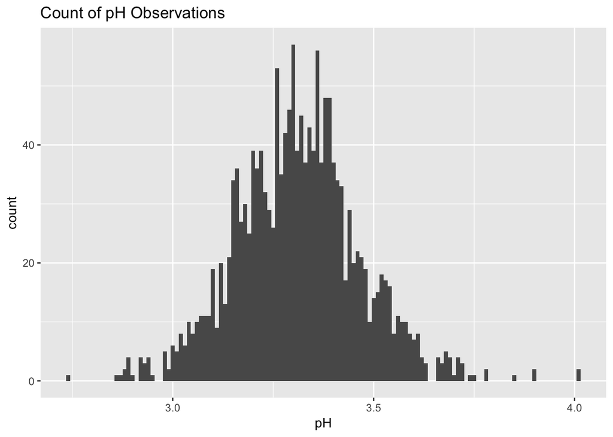

```
##    Min. 1st Qu.  Median    Mean 3rd Qu.    Max.
##   2.740   3.210   3.310   3.311   3.400   4.010
```

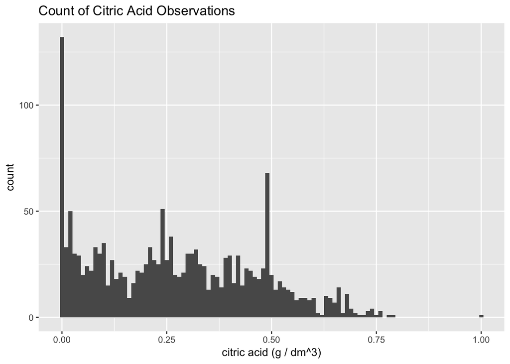

```
##    Min. 1st Qu.  Median    Mean 3rd Qu.    Max.
##   0.000   0.090   0.260   0.271   0.420   1.000
```

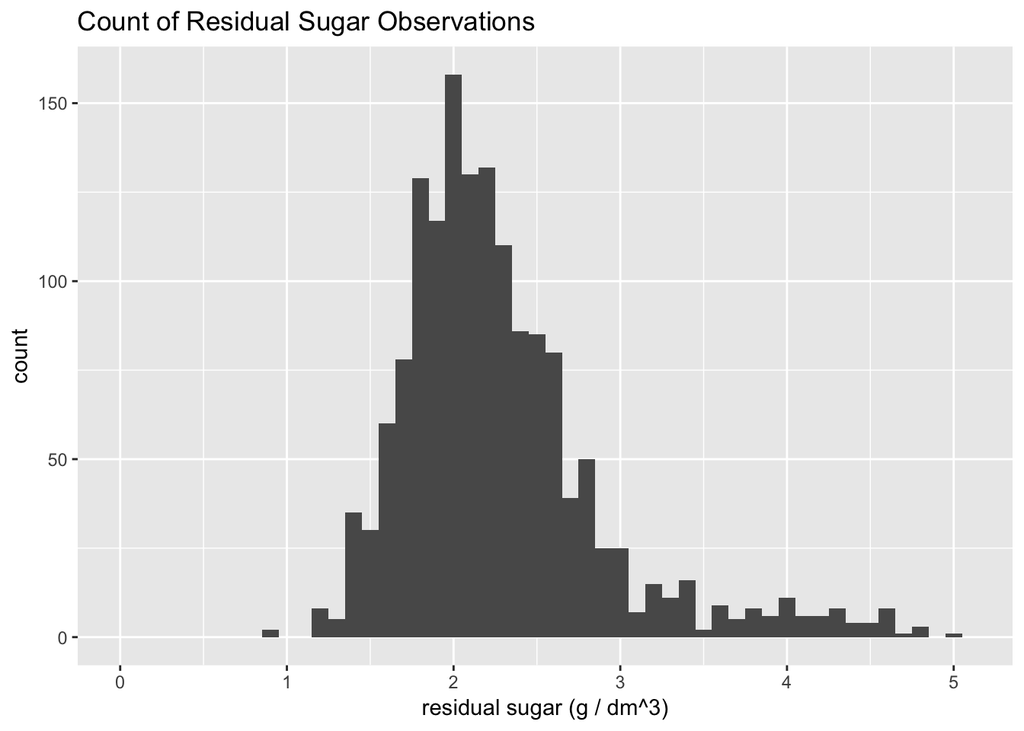

```
##    Min. 1st Qu.  Median    Mean 3rd Qu.    Max.
##   0.900   1.900   2.200   2.539   2.600  15.500
```

A limit on the value of residual.sugar was placed in order to focus on the bulk of the data. Most wines have a sugar level around 2 although there are some outliers having a sugar level up to 15, causing the data to be skewed to the right.

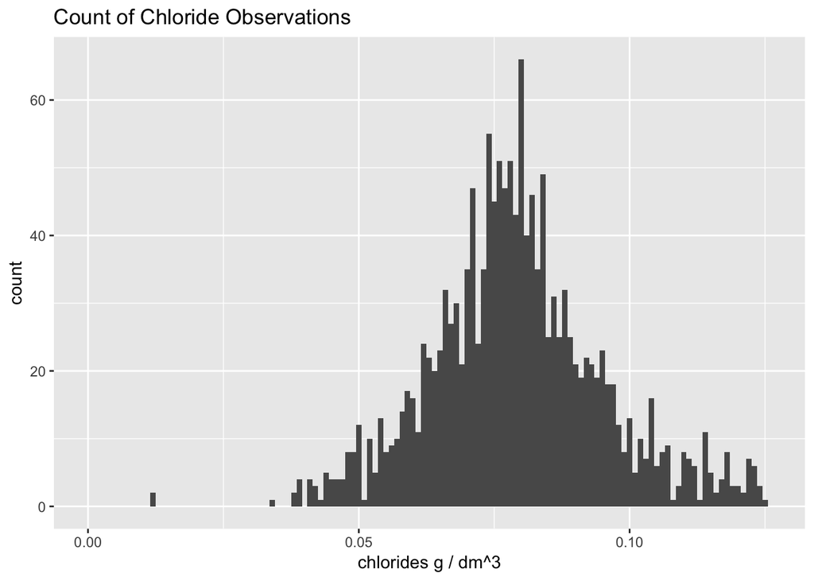

```
##    Min. 1st Qu.  Median    Mean 3rd Qu.    Max.
## 0.01200 0.07000 0.07900 0.08747 0.09000 0.61100
```

A limit was placed on the value of chlorides to focus on the bulk of the data and ignore the outliers. The top 5% of values are ignored in this plot. The observations of chloride seem to be the most normally distributed variable.

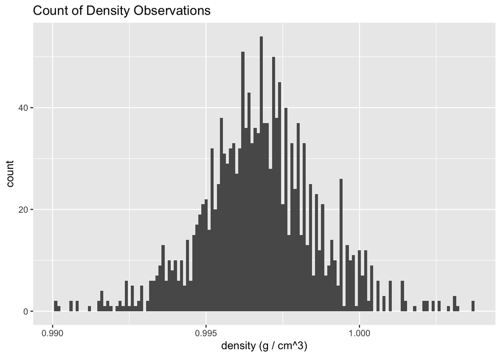

```
##    Min. 1st Qu.  Median    Mean 3rd Qu.    Max.
##  0.9901  0.9956  0.9968  0.9967  0.9978  1.0037
```

The density variable appears to be normally distributed.

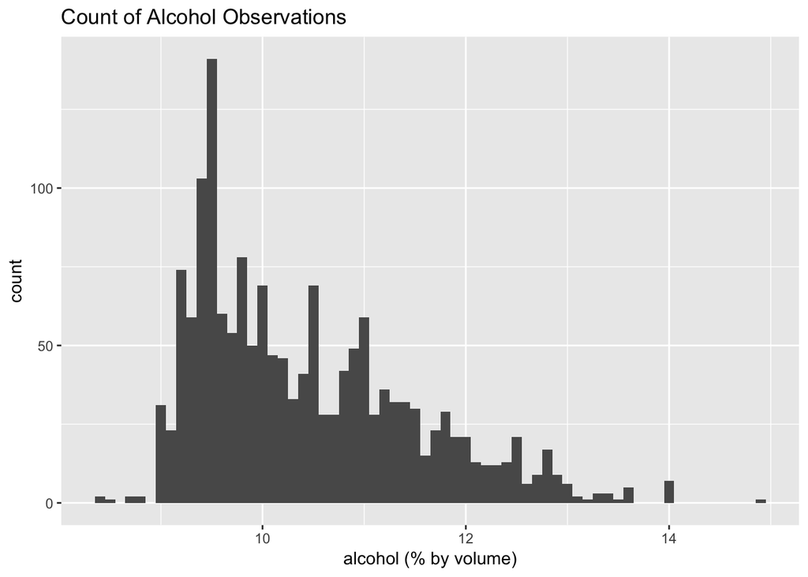

```
##    Min. 1st Qu.  Median    Mean 3rd Qu.    Max.
##    8.40    9.50   10.20   10.42   11.10   14.90
```

The variable alcohol is skewed towards the right, with most observations having an alcohol rating of 9.5.

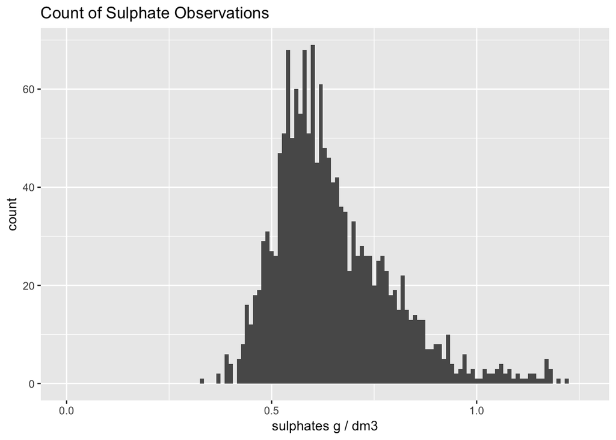

```
##    Min. 1st Qu.  Median    Mean 3rd Qu.    Max.
##  0.3300  0.5500  0.6200  0.6581  0.7300  2.0000
```

The sulphate variable was the most heavily skewed variable. The top one percent of data is ignored in this plot to avoid seeing overly dispersed data.

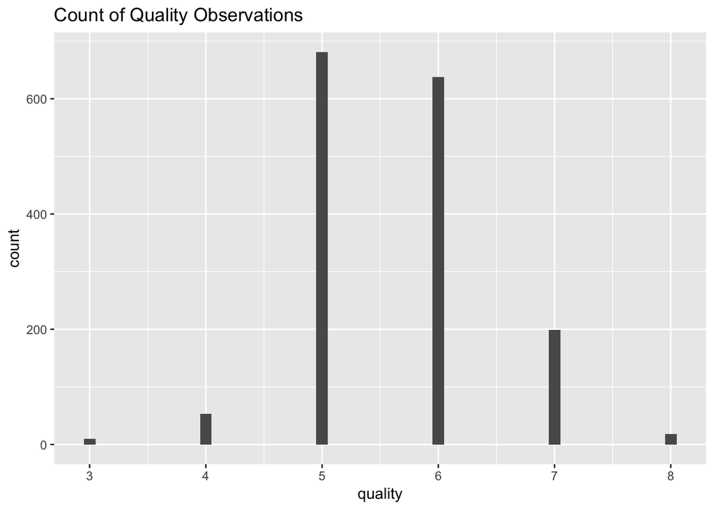

```
##    Min. 1st Qu.  Median    Mean 3rd Qu.    Max.
##   3.000   5.000   6.000   5.636   6.000   8.000
```

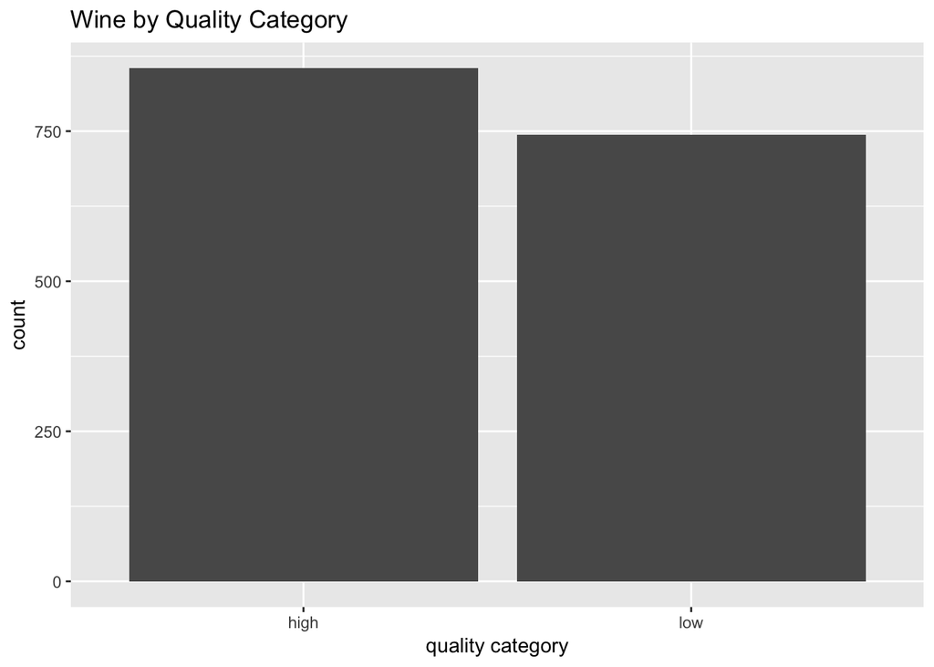

```
##    Length     Class      Mode
##      1599 character character
```

# Univariate Analysis

### What is the structure of your dataset?

The structure of the data set includes 1599 observations with 13 different variables.

### What is/are the main feature(s) of interest in your dataset?

The main feature of interest in this report is to view the trends among different wines grouped by quality.

### What other features in the dataset do you think will help support your investigation into your feature(s) of interest?

I believe that there will be a negative relationship between acidity(pH) and quality as it’s generally thought that higher quality wines have lower the pH. I also hope to find that the wines containing the highest and lowest residual sugar values will be classified under lower quality ratings as I presume that those wines will be classified as low quality due to the imbalance of sweetness.

### Of the features you investigated, were there any unusual distributions? Did you perform any operations on the data to tidy, adjust, or change the form of the data? If so, why did you do this?

In order to tidy the data, I adjusted the binwidths on plots with variables such as pH, citric.acid, and residual.sugar because the data points consisted of data that was calculated to the tenth or hundredth decimal place. This was to prevent rounding of the data that would cause the plots over cluster the data and make it difficult to see the variations in the distributions. I also limited the values along the x-axis on some of the plots in order to focus the plots towards the bulk of the data and ignore the outliers.

# Bivariate Plots Section

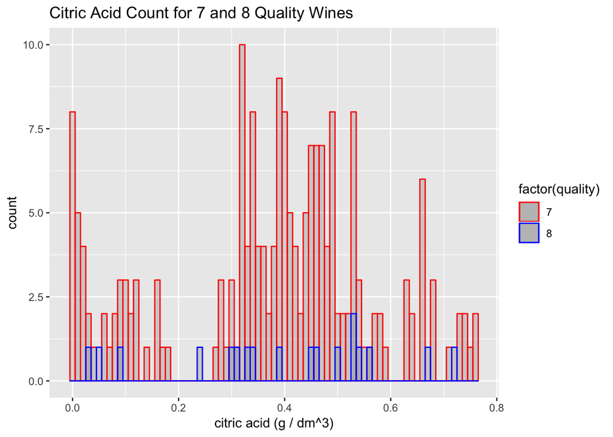

This plot shows that the highest quality wine (8) show no particular trends of citric acid levels, while most of the second highest quality of wines (7) have an citric acid level of 0 or between .3 and .5.

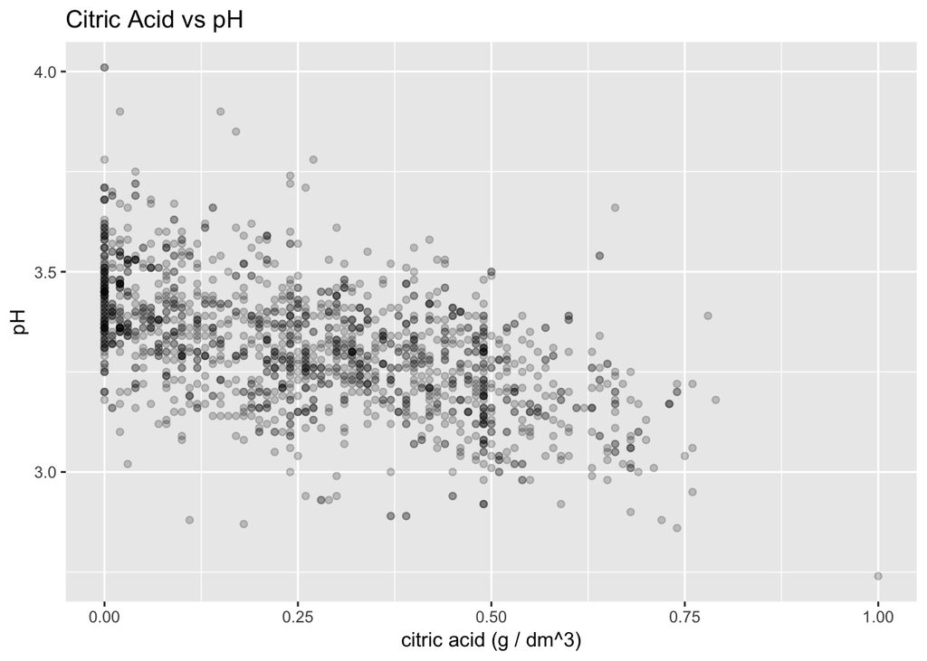

[output not shown]

There is a postive relationship between a wine’s citric acid level and overall acidity level (or negative in terms of pH level).

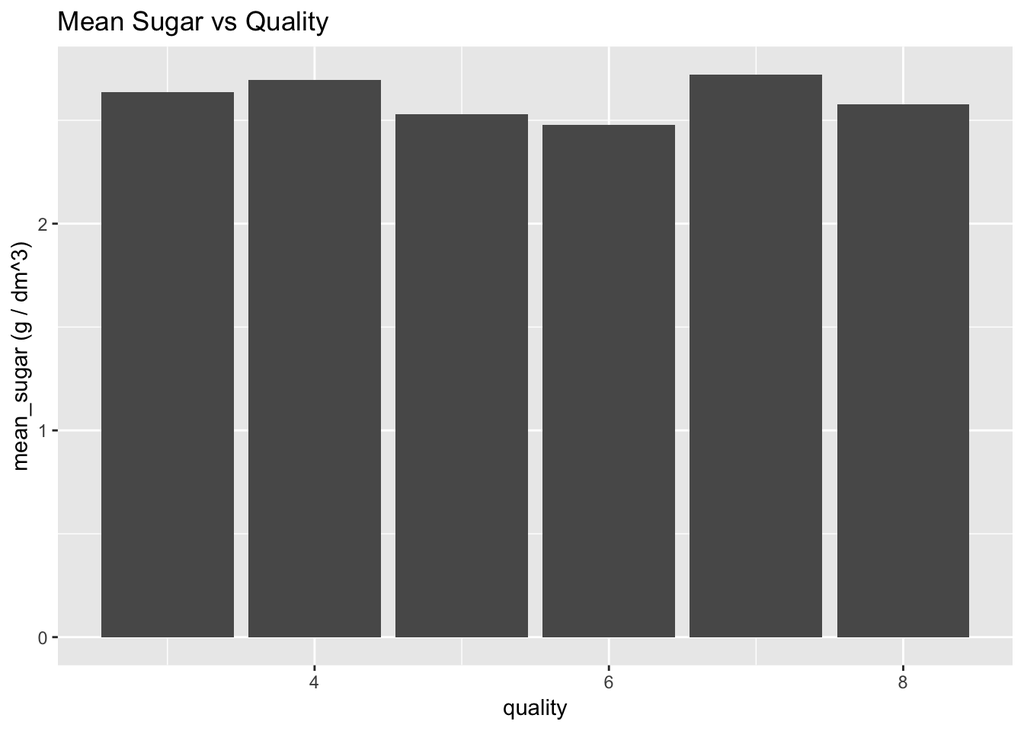

```
##
##  Pearson's product-moment correlation
##
## data:  wine_qualities$mean_sugar and wine_qualities$quality
## t = -0.29461, df = 4, p-value = 0.783
## alternative hypothesis: true correlation is not equal to 0
## 95 percent confidence interval:
##  -0.8560477  0.7551407
## sample estimates:
##        cor
## -0.1457305
```

There’s very low correlation between a wine’s residual sugar levels and its quality rating.

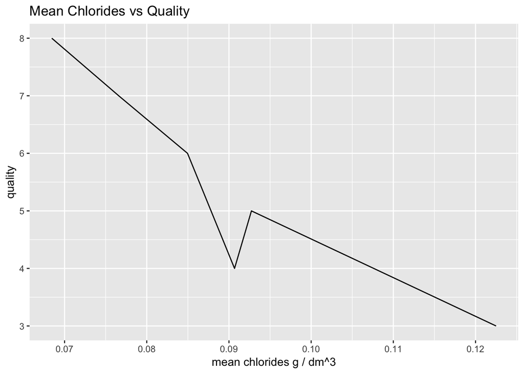

```
##
##  Pearson's product-moment correlation
##
## data:  wine_qualities$mean_chlorides and wine_qualities$quality
## t = -4.6997, df = 4, p-value = 0.009311
## alternative hypothesis: true correlation is not equal to 0
## 95 percent confidence interval:
##  -0.9913852 -0.4287654
## sample estimates:
##        cor
## -0.9201445
```

This plot shows that as chloride content decreases, quality rating increases.  
There is a noticeable dip for moderate quality wines.

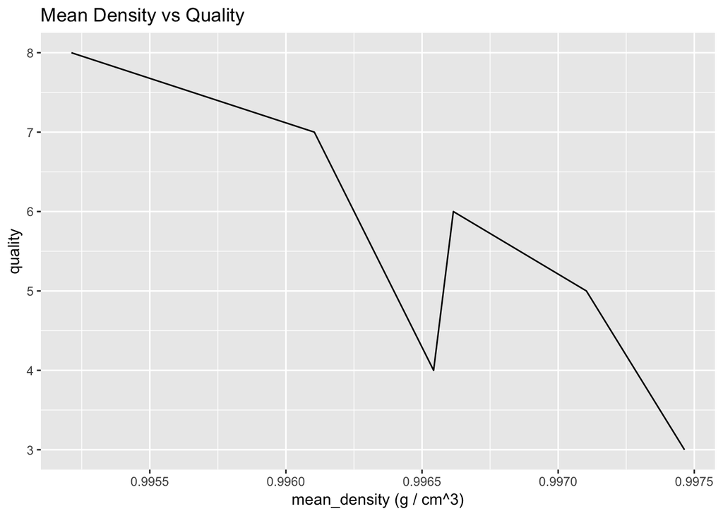

```
##
##  Pearson's product-moment correlation
##
## data:  wine_qualities$mean_density and wine_qualities$quality
## t = -3.7698, df = 4, p-value = 0.01961
## alternative hypothesis: true correlation is not equal to 0
## 95 percent confidence interval:
##  -0.9872005 -0.2537030
## sample estimates:
##        cor
## -0.8833802
```

This plot shows that higher quality wines are more likely to have a lower density.

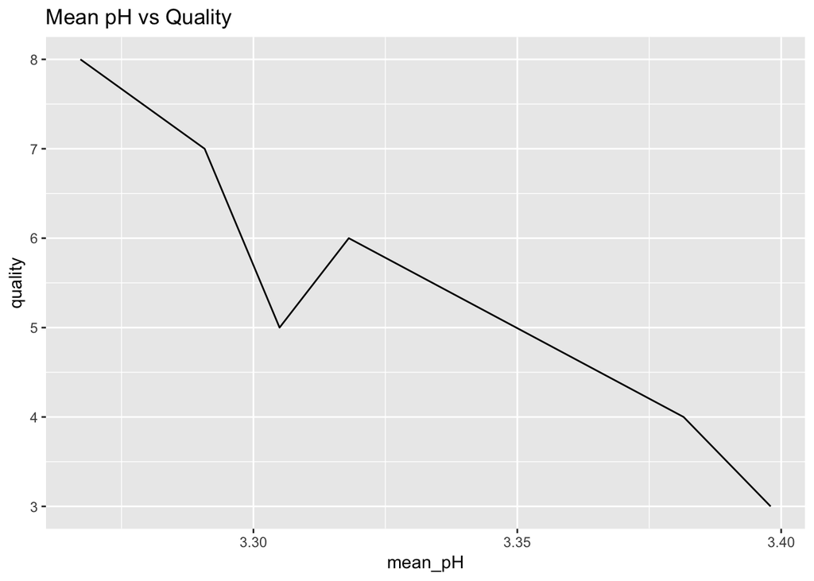

```
##
##  Pearson's product-moment correlation
##
## data:  wine$pH and wine$quality
## t = -2.3109, df = 1597, p-value = 0.02096
## alternative hypothesis: true correlation is not equal to 0
## 95 percent confidence interval:
##  -0.106451268 -0.008734972
## sample estimates:
##         cor
## -0.05773139
```

This plot shows that as quality decreases, pH also increases but very slightly.

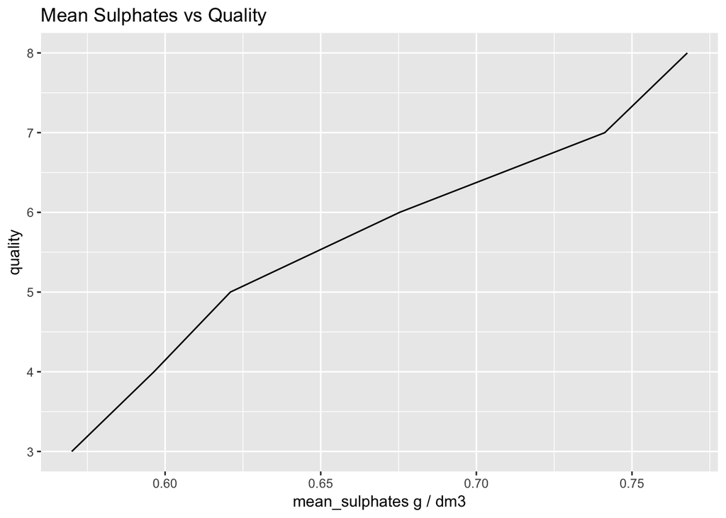

```
##
##  Pearson's product-moment correlation
##
## data:  wine_qualities$mean_sulphates and wine_qualities$quality
## t = 11.777, df = 4, p-value = 0.0002975
## alternative hypothesis: true correlation is not equal to 0
## 95 percent confidence interval:
##  0.8720744 0.9985223
## sample estimates:
##       cor
## 0.9858842
```

This plot shows the positive relationship between quality and mean_sulphates. This plot was also one of the only ones to not show the moderate quality wines breaking the trend between the high vs low quality wines.

# Bivariate Analysis

### Talk about some of the relationships you observed in this part of the investigation. How did the feature(s) of interest vary with other features in the dataset?

After analyzing different relationships between different variables in the data set, it has been discovered that a lot of the variables were weakly correlated to the variable of quality including; acidity, sugar, chloride, density, sulphates unless you correlate the mean value of each variable in relation to quality. Mean residual sugar showdd the weakest correlation to quality while mean sulphates showed the strongest correlation to quality.

### What was the strongest relationship you found?

The strongest relationship found was the correlation between sulphates and quality rating at 0.9859.

# Multivariate Plots Section

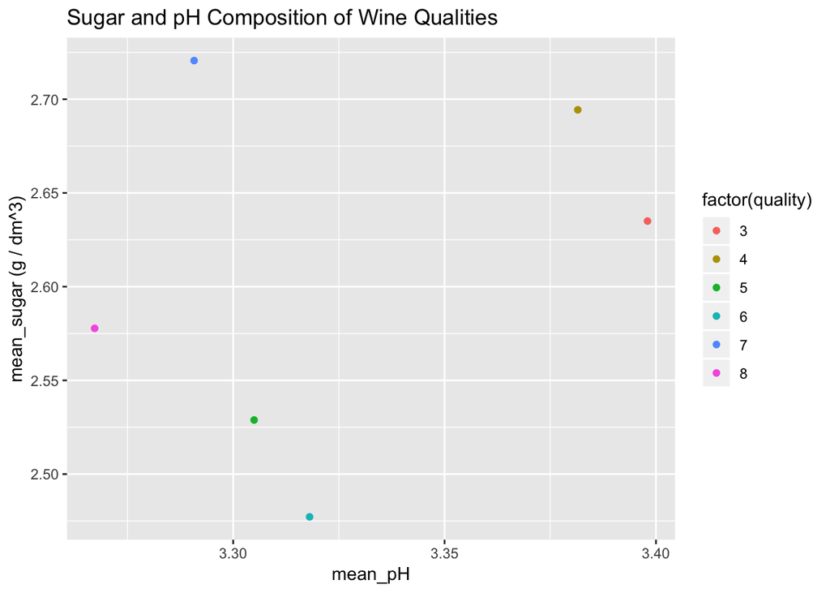

[figure not shown]

This plot’s purpose is to illustrate the mean composition of different quality wines in terms of acidity and sugar. There appears to be no trend between pH and sugar composition among the different quality of wines.

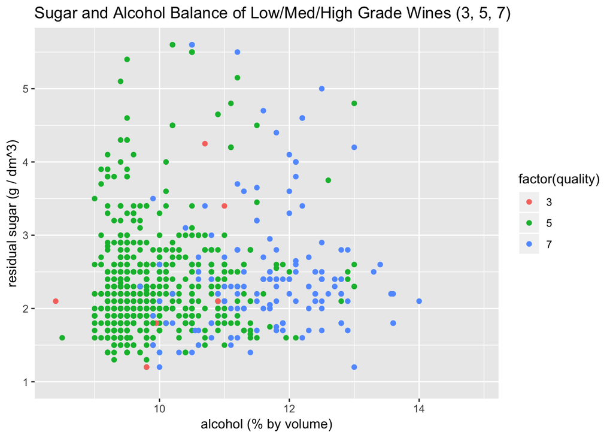

This plot shows that sugar does not increase as alcohol content increases. It also shows that higher quality wines tend to have more alcohol than lower quality wines.

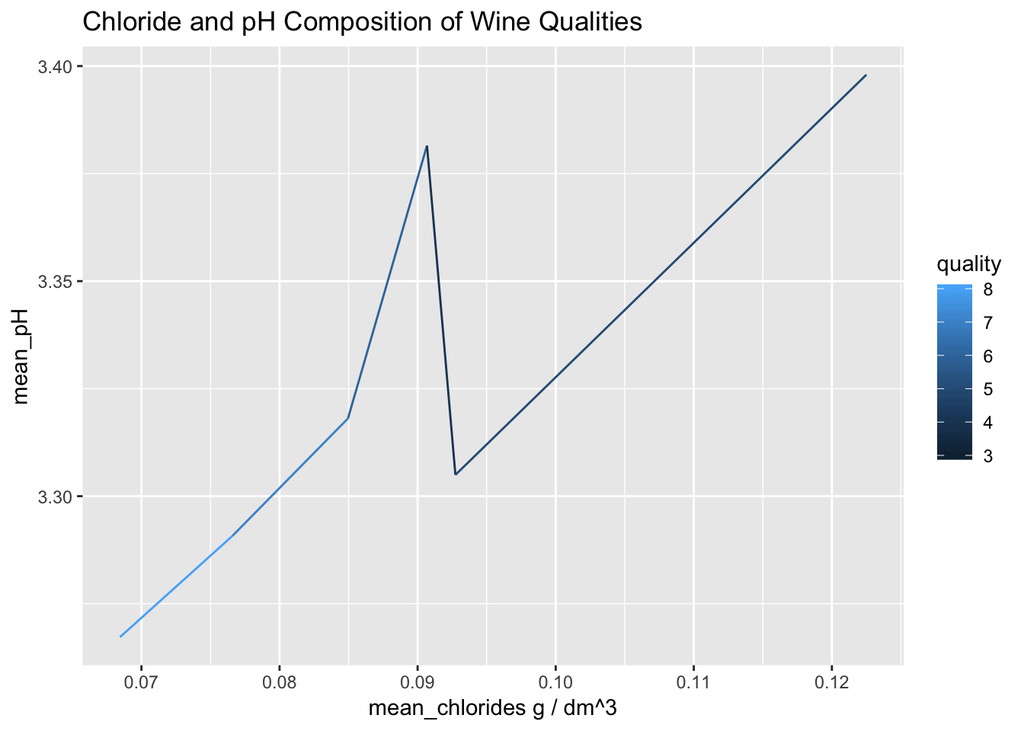

# Multivariate Analysis

### Talk about some of the relationships you observed in this part of the investigation. Were there features that strengthened each other in terms of looking at your feature(s) of interest?

The relationships observed in the multivariant analysis included the observation of sugar and pH content among different qualities of wine, the combination of alcohol and sugar content among the different wine qualities, and the mean chloride and pH level among different wine qualities. The main takeway from the previous three plots is that it is difficult to see a distinction between sugar content and the quality of wine even when paired with other variables such as pH, chloride content, and alcohol content.

### Were there any interesting or surprising interactions between features?

When all three plots are examined together it is revealed the residual sugar content would play little if any role being able to predict a wines quality. It was also interesting to see the high quality wines and low quality wines both shared the characteristic of containing relatively high amounts of sugar. The differentiating factor may be the sugar content in higher quality wines is balanced out by the higher alcohol content.

### OPTIONAL: Did you create any models with your dataset? Discuss the strengths and limitations of your model.

N/A

# Final Plots and Summary

### Plot One

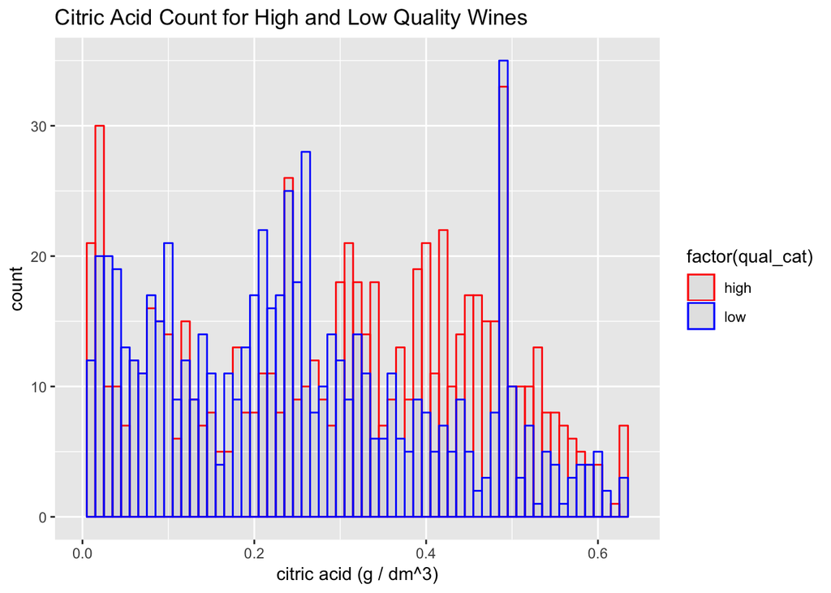

### Description One

This plot shows the distribution of different citric acid levels between low quality wines and high quality wines. The low quality wines are wines rated from 3-5 while the high quality wines are rated 6-8. The distribution of low quality wines appear to be slightly more weighted to the lower citric acid levels while the higher quality wines appear to be slightly more weighted to the higher citric acid levels.

### Plot Two

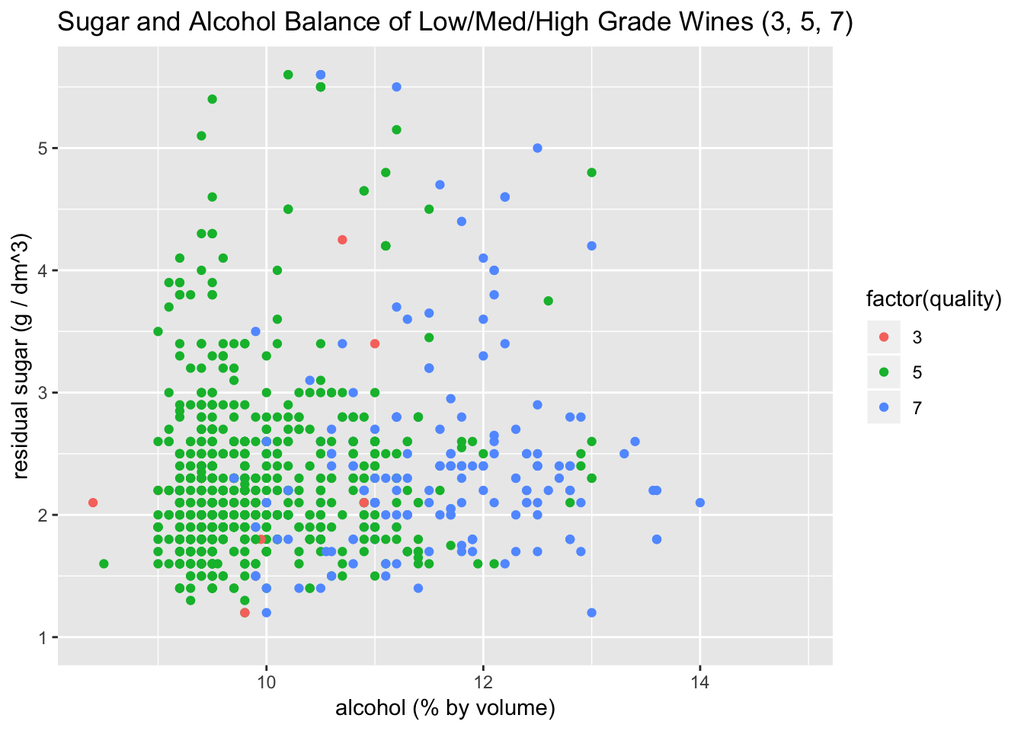

### Description Two

This plot was created to see if sugar and alcohol balance had anything to do with a wine’s quality. This plot reveals sugar is irrelevent to a wines quality given its alcohol content. The plot also reveals that higher quality wines tend to contain more alcohol relative to lower quality wines.

### Plot Three

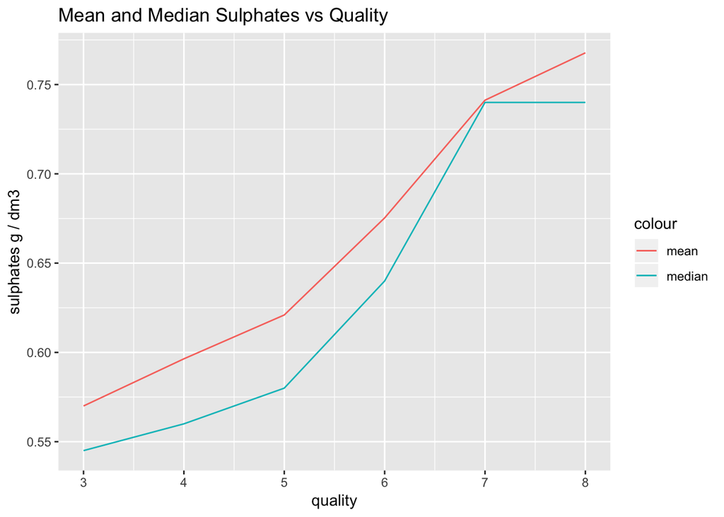

### Description Three

This plot illustrates the strongest correlation in the data set which is the relationship between wine quality and sulphate amount. I added the median line in the graph to provide more statistical evidence that sulphate is strongly, positively correlated with wine quality.

# Reflection

Overall this project opened to my eyes to how trends may not be as easily visible by looking at the raw data. Trends may be hidden because of the skewing caused by the over dispersion of data, the overcrowding of data points, or approaching the data itself in the wrong way. At first I struggled to find any meaningful relationships when I looked at the data with minimal manipulation. Once I’ve gotten to seperating the data set into different groups by wine quality and looking at the means of the other variables, it became easier to see trends and relationships. It was suprising to see that, despite my prediction, there was no trend in combinations of variables of pH and sugar, acidity and sugar, and alcohol and sugar when it came to predicting wine quality. I thought that higher wine qualities would share similar characteristics of a balance of sweet/salty, sweet/acidic, or sweet/alcohol. I was wrong. In the future, one may further examine this data set by taking an even sample from each wine quality group and conduct analysis of the variables to make up for the unequal representation of each wine quality in the data set.